# QM_HW_4

### HW4

**Well-behaved functions requirements**:

- $\exists \int \psi^{*}(x) \psi(x) d x \space\space\space\space\space\space\space\space\space\space\space$ Normalizable
- $\exists ! \psi(x) \space\space\space\space\space\space\space\space\space\space\space\space\space\space\space\space\space\space\space\space\space\space\space\space\space\space\space\space$ Univalued
- $\lim _{x \rightarrow a} \psi(x)=\psi(a) \space\space\space\space\space\space\space$ Continuous
- $\lim _{x \rightarrow a} \frac{d \psi(x)}{d x}=\frac{d \psi(a)}{d x}\space\space\space\space\space\space$ Continuous first derivative

**Two operators commute if and only if they have the same eigenvectors.**

**Ladder Operator in Harmonic oscillator**: $ b=\left(\frac{m \omega}{2 \hbar}\right)^{\frac{1}{2}}\left(x+\frac{i p}{m \omega}\right), b^{\dagger}=\left(\frac{m \omega}{2 \hbar}\right)^{\frac{1}{2}}\left(x-\frac{i p}{m \omega}\right) $

- **Eigenfunctions** $b^{\dagger} \varphi_{n}(x)=\sqrt{n+1} \varphi_{n+1}(x)$

**Rotation in QM**: $\hat{L}_{x}=-i \hbar\left(y \frac{\partial}{\partial z}-z \frac{\partial}{\partial y}\right); \hat{L}_{y}=-i \hbar\left(z \frac{\partial}{\partial x}-x \frac{\partial}{\partial z}\right); \hat{L}_{z}=-i \hbar\left(x \frac{\partial}{\partial y}-y \frac{\partial}{\partial x}\right)$

**Rotation Ladder Operator**: $L_{+}=L_{x}+i L_{y}; L_{-}=L_{x}-i L_{y}$

1.$\space$ a) Well-behaved. Since it satisfies the above requirements when $x \in[0,1]$.

$\space$$\space$$\space$$\space$ b) Well-behaved. Since it satisfies the above requirements when $x \in[1,2]$.

$\space$$\space$$\space$$\space$ c) Not well-behaved. Since the first derivative is not continuous at $x=0$ as the following shows:

If $x > 0$, $\lim _{x \rightarrow0^{+}} \frac{|0+x|-|0|}{x}=\lim _{x\rightarrow0^{+}} \frac{|x|}{x}=\lim _{x\rightarrow0^{+}} 1=1$; if $x < 0$, $\lim _{x\rightarrow0^{-}} \frac{|0+x|-|0|}{x}=\lim _{x\rightarrow0^{-}} \frac{|x|}{x}=\lim _{x\rightarrow0^{-}}-1=-1$.

2.$\space$ $\hat{H}=\hat{T}+\hat{V}(x) = -\frac{\hbar^{2}}{2 m} \frac{d^{2} }{d x^{2}}+\frac{k}{2} x^{2} ;\space \hat{V}(x)=\frac{k}{2} x^{2}$

$\hat{H}\hat{V}f = (-\frac{\hbar^{2}}{2 m} \frac{d^{2} }{d x^{2}}+\frac{k}{2} x^{2})\frac{k}{2} x^{2}f = -\frac{\hbar^{2}k}{4 m} \frac{d^{2} (x^{2}f)}{d x^{2}}+ \frac{k^2}{4} x^{4}f$

$\hat{V}\hat{H}f = \frac{k}{2} x^{2}(-\frac{\hbar^{2}}{2 m} \frac{d^{2} }{d x^{2}}+\frac{k}{2} x^{2})f = -\frac{\hbar^{2}k}{4 m} x^{2}\frac{d^{2} f}{d x^{2}}+ \frac{k^2}{4} x^{4}f$

Since $\frac{d^{2} (x^{2}f)}{d x^{2}} \neq x^{2}\frac{d^{2} f}{d x^{2}}$, $[\hat{H}, \hat{V}] = \hat{H}\hat{V}- \hat{V}\hat{H} \neq 0$, so following the fact that "Two operators commute if and only if they have the same eigenvectors.", there is no eigenfunctions of the total energy that will also be eigenfunctions of the potential energy.

3.$\space$ $\Lambda \approx 16 \frac{E}{U_{0}}\left(1-\frac{E}{U_{0}}\right) \exp \left(-2 L \sqrt{\frac{2}{m \hbar^{2}}\left(U_{0}-E\right)}\right)$

a) $\Lambda_a \approx 16 \frac{E(1-0.1)}{U_{0}(1-0.1)}\left(1-\frac{E(1-0.1)}{U_{0}(1-0.1)}\right) \exp \left(-2 L \sqrt{\frac{2}{m \hbar^{2}}\left(U_{0}(1-0.1)-E(1-0.1)\right)}\right) \approx 16 \frac{E}{U_{0}}\left(1-\frac{E}{U_{0}}\right) \exp \left(-2\sqrt{0.9} L \sqrt{\frac{2}{m \hbar^{2}}\left(U_{0}-E\right)}\right)$

b) $\Lambda_b \approx 16 \frac{E}{U_{0}}\left(1-\frac{E}{U_{0}}\right) \exp \left(-2 L(1-0.1) \sqrt{\frac{2}{m \hbar^{2}}\left(U_{0}-E\right)}\right) \approx 16 \frac{E}{U_{0}}\left(1-\frac{E}{U_{0}}\right) \exp \left(-1.8 L \sqrt{\frac{2}{m \hbar^{2}}\left(U_{0}-E\right)}\right)$

Assuming $E<U_{0}$, then $\frac{\Lambda_a}{\Lambda_b} = \exp(-(\sqrt{0.9} - 0.9)L \sqrt{\frac{2}{m \hbar^{2}}(U_{0}-E)} ) < 1$, so b) will result in a bigger increment in the transmission coefficient.

4.$\space$ $b^{\dagger} \varphi_{n}(x)=\sqrt{n+1} \varphi_{n+1}(x) \\ \varphi_{0}(x)=N_{0} e^{-\alpha \frac{x^{2}}{2}}, \alpha=\frac{m \omega}{\hbar} \\ \varphi_{1}(x)=\frac{1}{\sqrt{0+1}} b^{\dagger} \varphi_{0}(x) =N_0 \sqrt{\frac{2 m \omega}{\hbar}} x e^{-\alpha x^{2} / 2 }\\ \varphi_{2}(x)=\frac{1}{\sqrt{1+1}} b^{\dagger} \varphi_{1}(x) = \frac{1}{\sqrt{1+1}}\left(\frac{m \omega}{2 \hbar}\right)^{\frac{1}{2}}\left(x-\frac{\hbar}{m \omega} \frac{d}{d x}\right) \varphi_{1}(x) = \frac{\sqrt{2}}{2}N_0(2\alpha x^2 - 1)e^{-\alpha x^{2} / 2 }$

5.$\space$a) $\hat{L}_{y} \hat{L}_{z} f=-\hbar^{2}\left(z \frac{\partial f}{\partial y}+z x \frac{\partial^{2} f}{\partial x \partial y}-z y \frac{\partial^{2} f}{\partial x^{2}}-x^{2} \frac{\partial^{2} f}{\partial z \partial y}+x y \frac{\partial^{2} f}{\partial z \partial x}\right)$

$\space$$\space$$\space$$\hat{L}_{z} \hat{L}_{y} f=-\hbar^{2}\left(y \frac{\partial f}{\partial z}+y x \frac{\partial^{2} f}{\partial x \partial z}-z y \frac{\partial^{2} f}{\partial x^{2}}-x^{2} \frac{\partial^{2} f}{\partial y \partial z}+x z \frac{\partial^{2} f}{\partial y \partial x}\right)$

$\space$$\space$$\space$$\hat{L}_{y} \hat{L}_{z} f - \hat{L}_{z} \hat{L}_{y} f = -\hbar^{2}(z \frac{\partial f}{\partial y} -y \frac{\partial f}{\partial z} ) \rightarrow \left[\hat{L}_{y}, \hat{L}_{z}\right]=i \hbar \hat{L}_x$

By noticing the cyclic permutation of $x$, $y$, and $z$ in definition of $\hat{L}_{x}, \hat{L}_{y}$ and $\hat{L}_{z}$, we can replace $x$ by $y$, replace $y$ by $z$, and replace $z$ by $x$, then we get $\space$$\space$$\space$$\hat{L}_{z} \hat{L}_{x} f - \hat{L}_{x} \hat{L}_{z} f = -\hbar^{2}(x \frac{\partial f}{\partial z} -z \frac{\partial f}{\partial x} ) \rightarrow \left[\hat{L}_{z}, \hat{L}_{x}\right]=i \hbar \hat{L}_y$

$\space$b) $\left[\hat{L}^{2}, \hat{L}_{x}\right] =\left[\hat{L}_{x}^{2}+\hat{L}_{y}^{2}+\hat{L}_{z}^{2}, \hat{L}_{x}\right] \\ =\left[\hat{L}_{x}^{2} \hat{L}_{x}\right]+\left[\hat{L}_{y}^{2} \hat{L}_{x}\right]+\left[\hat{L}_{z}^{2}, \hat{L}_{x}\right] \\ =\left[\hat{L}_{y}^{2}, \hat{L}_{x}\right]+\left[\hat{L}_{z}^{2}, \hat{L}_{x}\right] \\ =\left[\hat{L}_{y}, \hat{L}_{x}\right] \hat{L}_{y}+\hat{L}_{y}\left[\hat{L}_{y}, \hat{L}_{x}\right]+\left[\hat{L}_{z}, \hat{L}_{x}\right] \hat{L}_{z}+\hat{L}_{z}\left[\hat{L}_{z}, \hat{L}_{x}\right] \\ =-i \hat{h} \hat{L}_{z} \hat{L}_{y}-i \hbar \hat{L}_{y} \hat{L}_{z}+i \hbar \hat{L}_{y} \hat{L}_{z}+i \hbar \hat{L}_{z} \hat{L}_{y} = 0$

Similarly, we get $\left[\hat{L}^{2}, \hat{L}_{y}\right] =-i \hat{h} \hat{L}_{x} \hat{L}_{z}-i \hbar \hat{L}_{z} \hat{L}_{x}+i \hbar \hat{L}_{z} \hat{L}_{x}+i \hbar \hat{L}_{x} \hat{L}_{z} = 0 $

**Optional**:

$ \hat{L}_{+} \hat{L}_{-}=\left(\hat{L}_{x}+i \hat{L}_{y}\right)\left(\hat{L}_{x}-i \hat{L}_{y}\right)=\hat{L}_{x}\left(\hat{L}_{x}-i \hat{L}_{y}\right)+i \hat{L}_{y}\left(\hat{L}_{x}-i \hat{L}_{y}\right) \\ = \hat{L}_{x}^{2}-i \hat{L}_{x} \hat{L}_{y}+i \hat{L}_{y} \hat{L}_{x}+\hat{L}_{y}^{2}=\hat{L}^{2}-\hat{L}_{z}^{2}+i\left[\hat{L}_{y}, \hat{L}_{x}\right]$

$\hat{L}_{+} \hat{L}_{-} =\hat{L}^{2}-\hat{L}_{z}^{2}+\hbar \hat{L}_{z} $

Similarly, we get $\hat{L}_{-} \hat{L}_{+}=\hat{L}^{2}-\hat{L}_{z}^{2}-\hbar \hat{L}_{z}$, so $\left[L_{+}, L_{-}\right]= L_{+}L_{-} - L_{-} L_{+} = 2 \hbar L_{z}$

### HW5

The functions $f$ and $g$ are **orthogonal** when $\langle f| g\rangle = 0$.

**Real H like wave function:**

$\psi_{1 s}=\frac{1}{\pi^{1 / 2}}\left(\frac{Z}{a}\right)^{3 / 2} e^{-\mathrm{Zr} / a}$

$\psi_{2 s}=\frac{1}{4(2 \pi)^{1 / 2}}\left(\frac{Z}{a}\right)^{3 / 2}\left(2-\frac{Z r}{a}\right) e^{-\mathrm{Zr} / 2 a}$

$\psi_{2 p_{x}}=\frac{1}{4(2 \pi)^{1 / 2}}\left(\frac{Z}{a}\right)^{5 / 2} r e^{-\mathrm{Zr} / 2 a} \sin \theta \cos \phi$

$\psi_{2 p_{y}}=\frac{1}{4(2 \pi)^{1 / 2}}\left(\frac{Z}{a}\right)^{5 / 2} r e^{-\mathrm{Zr} / 2 a} \sin \theta \sin \phi$

**Radial probability density:** $\rho(r)=R_{n, l}^{2}(r) r^{2}$

**Average value**: $\langle x\rangle=\int_{\text {measure space }} x p(x) d x$

**Particle on a sphere:** $E=\frac{\hbar^{2} j(j+1)}{2 I} ; j=0,1,2, \ldots$; $I = mr^2$

**Z component of the angular momentum:** $L_{z} \psi=m_{j} \hbar \psi$; $m_{j}=0,\pm 1,\pm 2, \ldots$

**Integral for question 3:** $\int_{0}^{\infty} x^{n} e^{-q x} d x=\frac{n !}{q^{n+1}}, \quad n>-1, q>0$

1.$\space$$ \langle \psi_{2 p_x}| \psi_{2 p_y}\rangle = \int_{0}^{2 \pi} \int_{0}^{\pi} \int_{0}^{\infty} \psi_{2 p_x}^{*} \psi_{2 p_y} r^{2} d r \sin \theta d \theta d \phi$

By integrating $r,\theta, \phi $ seperately, we found that $\int_{0}^{2 \pi} \cos \phi \sin \phi d \phi=\left.\frac{1}{2} \sin ^{2} \phi\right|_{0} ^{2 \pi}=0$, then we get $ \langle \psi_{2 p_x}| \psi_{2 p_y}\rangle = C*0 = 0$, where $C$ is the integration over $r,\theta$, so $\psi_{2 p_x} $ and $ \psi_{2 p_y}$ are mutually orthogonal.

2.$\space$ From $\rho(r)=R_{n, l}^{2}(r) r^{2}$, we get the probability of finding the electron within a distance “d” from the nucleus is $\int_{0}^{d} R_{n, l}^{2} r^{2} d r$. For hydrogen atom $R_{1,0}$, $\int_{0}^{d} R_{1, 0}^{2} r^{2} d r = \frac{4}{a^{3}} \int_{0}^{d} e^{-2 r / a} r^{2} d r=\left.\frac{4}{a^{3}} e^{-2 r / a}\left(-\frac{r^{2} a}{2}-\frac{2 r a^{2}}{4}-\frac{2 a^{3}}{8}\right)\right|_{0} ^{d} = \frac{4}{a^{3}} e^{-2 d / a}\left(-\frac{d^{2} a}{2}-\frac{2 d a^{2}}{4}-\frac{2 a^{3}}{8}\right) + \frac{2 a^{3}}{8}$

3.$\space$$\langle r\rangle=\int_{0}^{2 \pi} \int_{0}^{\pi} \int_{0}^{\infty} r \psi_{2 s}^{*} \psi_{2 s} r^{2} d r \sin \theta d \theta d \phi$

$=\frac{1}{32 \pi}\left(\frac{1}{a}\right)^{3} \int_{0}^{2 \pi} \int_{0}^{\pi} \int_{0}^{\infty}\left[\left(2-\frac{r}{a}\right) e^{-r / 2 a}\right]^{2} r^{3} d r \sin \theta d \theta d \phi$

$=\frac{1}{32 \pi}\left(\frac{1}{a}\right)^{3} \int_{0}^{2 \pi} \int_{0}^{\pi} \int_{0}^{\infty}\left(4-\frac{4 r}{a}+\left(\frac{r}{a}\right)^{2}\right) r^{3} e^{-r / a} d r \sin \theta d \theta d \phi$

$=\frac{1}{32 \pi}\left(\frac{1}{a}\right)^{3} \int_{0}^{2 \pi} \int_{0}^{\pi}\int_{0}^{\infty}\left(4 e^{-r / a}-\frac{4 r}{a} e^{-r / a}+\left(\frac{r}{a}\right)^{2} e^{-r / a}\right) r^{3} d r \sin \theta d \theta d \phi$

$=\frac{1}{8}\left(\frac{1}{a}\right)^{3} \int_{0}^{\infty}\left(4 e^{-r / a}-\frac{4 r}{a} e^{-r / a}+\left(\frac{r}{a}\right)^{2} e^{-r / a}\right) r^{3} d r$

$=\frac{1}{8}\left(\frac{1}{a}\right)^{3} \int_{0}^{\infty} 4 r^{3} e^{-r / a}-\frac{4 r^{4}}{a} e^{-r / a}+\left(\frac{r}{a}\right)^{2} r^{3} e^{-r / a} d r$

$=6a$, which is larger than the maximum of the radial probability from the following plot for radial distribution function of $2s$.

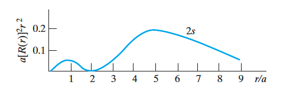

```python
from IPython.display import Image
Image('2s_radial.png')
```

4.$\space$ $E_{abs} = hv = h\frac{c}{\lambda} = E_{j=1} - E_{j=0} = \frac{h^{2}}{4\pi^2m_er^2} \rightarrow r = \sqrt{\frac{h\lambda}{4\pi^2m_ec}}$

```python
print('D_1 =',round(np.sqrt(680*6.626/(4*(np.pi)**2*9.11*3))/10,3)*2,'nm')
print('D_2 =',round(np.sqrt(450*6.626/(4*(np.pi)**2*9.11*3))/10,3)*2,'nm')
```

[output not shown]

5.$\space$ $\frac{r^2R_{2s}^2}{r^2R_{1s}^2} = \frac{R_{2s}^2}{R_{1s}^2} = \frac{\frac{1}{2}\left(\frac{Z}{a}\right)^{3}\left(1-\frac{Z r}{2 a}\right)^2 e^{-\mathrm{Z} r / a}}{4\left(\frac{Z}{a}\right)^{3 } e^{-\mathrm{2Zr} / a}} = \frac{1}{8}\left(1-\frac{Z r}{2 a}\right)^2e^{\mathrm{Z} r / a} > 1 $ when $Z \geq 1; a = 0.53 Å; r = 2 Å$, so it is more likely for an electron to be at 2 Å from the nucleus in a 2s orbital.

**Optional:**

$\psi = c_1\psi_3 + c_2\psi_4$, $\psi, \psi_3, \psi_4$ are normalized.

$L_z\psi_3 = m_3\hbar \psi_3, m_3 = 0,\pm1,\pm2,\pm3$

$L_z\psi_4 = m_4\hbar \psi_4, m_4 = 0,\pm1,\pm2,\pm3, \pm4$

$L_z\psi = L_z|c_1\psi_3 + c_2\psi_4\rangle = c_1m_3\hbar\psi_3 + c_2m_4\hbar\psi_4$

$\langle L_z\rangle = \langle\psi | L_z | \psi\rangle = \langle c_1\psi_3 + c_2\psi_4 | L_z | c_1\psi_3 + c_2\psi_4\rangle = c_1^2m_3\hbar + c_2^2m_4\hbar; c_1^2+c_2^2 = 1$

From the above range of $c_1, c_2, m_3, m_4$, we get $\langle L_z\rangle = \langle\psi | L_z | \psi\rangle = c_1^2m_3\hbar + c_2^2m_4\hbar < 7\hbar$

a) Yes. We can let $c_1 = 1$ and $c_2 = 0$, then $L_z\psi = L_z|c_1\psi_3 + c_2\psi_4\rangle = c_1m_3\hbar\psi_3 + c_2m_4\hbar\psi_4 = m_3\hbar\psi_3$, and $m_3\hbar$ could be $-2\hbar$.

b) No. $\langle L_z\rangle < 7\hbar$ .See above.

c) Yes. We can let $c_1 = \sqrt{0.4}$ and $c_2 = \sqrt{0.6}$, then it is possible that $\langle L_z\rangle = c_1^2m_3\hbar+c_2^2m_4\hbar = (0.4*2+0.6*1)\hbar = 1.4\hbar$

## Exam 2

$b \varphi_{n}(x)=\sqrt{n} \varphi_{n-1}(x)$

$b^{\dagger} \varphi_{n}(x)=\sqrt{n+1} \varphi_{n+1}(x)$

$b \varphi_{0}(x)=0 \varphi_{0}(x)$

**Selection rule**: $\Delta J=\pm 1$ for absorptive rotational transitions.

**Average value of** $\mathbf{A}:\langle A\rangle=\frac{\int \psi^{*}(x) \hat{A} \psi(x) d x}{\int \psi^{*}(x) \psi(x) d x}=\frac{\langle\psi|A| \psi\rangle}{\langle\psi \mid \psi\rangle}$

1.$\space$ a) $\langle\psi_{2p_x} | L | \psi_{2p_x}\rangle = \sqrt{l(l+1)}\hbar\langle\psi_{2p_x} | \psi_{2p_x}\rangle = \sqrt{2}\hbar$

$\space$ b) $\langle\psi_{2p_x} | L^2 | \psi_{2p_x}\rangle = l(l+1)\hbar^2\langle\psi_{2p_x} | \psi_{2p_x}\rangle = 2\hbar^2$

$\space$ c) $\langle\psi_{2p_x} | L^2 | \psi_{2p_z}\rangle = l(l+1)\hbar^2\langle\psi_{2p_x} | \psi_{2p_z}\rangle = 2\hbar^2*0 = 0$

2.$\space$ 2.1 $\space$$E=h v\left(\frac{1}{2}+n\right) \rightarrow 1.325 \times 10^{-34}=h v(\frac{1}{2} + 3) \rightarrow v = 0.57$ Hz; $E_a = E_b = hv(\frac{1}{2}+3+1-3+3) = 9.44 \times 10^{-35} J $

2.2 $\space$ Using the above formula, we get $\varphi_{a}(x)=(b)^{3}\left(b^{\dagger}\right)^{3}(b) \varphi_{3}(x)=\sqrt{3 \cdot 3 \cdot 4 \cdot 5 \cdot 5 \cdot 4 \cdot 3} \varphi_{2}(x) = 60\sqrt{3}\varphi_{2}(x)$

$\varphi_{b}(x)=\left(b^{\dagger}\right)(b)^{4}\left(b^{\dagger}\right)^{2} \varphi_{3}(x)=\sqrt{4 \cdot 5 \cdot 5 \cdot 4 \cdot 3 \cdot 2 \cdot 2} \varphi_{2}(x) = 40\sqrt{3}\varphi_{2}(x)$

They lead to linearly-dependent eigenfunctions (so they have the same energy), but they are not the same eigenfunction.

2.3 $\space$ $\varphi_{b}(x) = (b^{\dagger})^{3} \sqrt{3\cdot 2 \cdot 1} b \varphi_{0} (x) = (b^{\dagger})^{3} \sqrt{3\cdot 2 \cdot 1}\cdot 0 \cdot \varphi_{0} (x) = 0 $

3.$\space$ $E_{S_1}=\frac{j(j+1)\hbar^{2}}{2 I} ;$ $\Delta J=\pm 1$ for absorptive rotational transitions. $\rightarrow E_{S_2}=\frac{(j+1)(j+2)\hbar^{2}}{2 I}; E_{S_3}=\frac{(j+2)(j+3)\hbar^{2}}{2 I}$

$hv_1 = E_{S_2}-E_{S_1} = \frac{(j+1)\hbar^{2}}{2 I};$ $hv_2 = E_{S_3}-E_{S_2} = \frac{(j+2)\hbar^{2}}{ I}$

$\frac{v_2}{v_1} = \frac{2(j+2)}{j+1} > 2 $ for $j = 0,1,2,3, ...$ Note that a rational number is a number that can be represented by the fraction of two integers and $\pi$ is irrational, so a) and b) are impossible.

4.$\langle\varphi_n| \varphi_n\rangle = 1 \rightarrow $normalized.$\space$ $E_n=\frac{n^{2} h^{2}}{8 ml}; n=1,2,3, \ldots$; $\space$ $\langle E_a\rangle = \frac{\langle\varphi_a|H| \varphi_a\rangle}{\langle\varphi_a \mid \varphi_a\rangle} $$\langle\varphi_a|H| \varphi_a\rangle = \left\langle\varphi_{a}\left|\left(\frac{1}{8} E_{2}|\varphi_2\rangle+\frac{1}{18} E_{3}|\varphi_3\rangle\right)\right.\right. =K\left\langle\varphi_{a}\left|\left(\frac{4}{8}|\varphi_2\rangle+\frac{9}{18}|\varphi_3\rangle\right)\right.\right. =\frac{K}{2}\left(\frac{1}{8}\left\langle \varphi_2\left|+\frac{1}{18}\langle \varphi_3|\right)(|\varphi_2\rangle+|\varphi_3\rangle)\right.\right. = \frac{K}{2}\left(\frac{1}{8}+\frac{1}{18}\right)$

$E_a = \frac{K}{2}\left(\frac{1}{8}+\frac{1}{18}\right) / \sqrt{\left(\frac{1}{8^{2}}+\frac{1}{18^{2}}\right)}; K=\frac{h^{2}}{8 m l}$

$\langle\varphi_b|H| \varphi_b\rangle = \left\langle\varphi_{b}\left|\left(\frac{1}{12} E_{2}|2\rangle+\frac{1}{27} E_{3}|3\rangle+\frac{1}{48} E_{4}|4\rangle\right)\right.\right. =K\left\langle\varphi_{b}\left|\left(\frac{4}{12}|2\rangle+\frac{9}{27}|3\rangle+\frac{16}{48}|4\rangle\right)\right.\right. =\frac{K}{3}\left(\frac{1}{12}\left\langle 2\left|+\frac{1}{27}\left\langle 3\left|+\frac{1}{48}\langle 4|\right)(|2\rangle+|3\rangle+|4\rangle)\right.\right.\right.\right.=\frac{K}{3}\left(\frac{1}{12}+\frac{1}{27}+\frac{1}{48}\right)$

$E_{b}=\frac{K}{3}\left(\frac{1}{12}+\frac{1}{27}+\frac{1}{48}\right) / \sqrt{\left(\frac{1}{12^{2}}+\frac{1}{27^{2}}+\frac{1}{48^{2}}\right)}; K=\frac{h^{2}}{8 m l}$

a) $\frac{E_{a}}{E_{b}}=\frac{9\left(\frac{1}{4}+\frac{1}{9}\right)}{4\left(\frac{1}{4}+\frac{1}{9}+\frac{1}{16}\right)} \frac{\sqrt{\left(\frac{1}{12^{2}}+\frac{1}{27^{2}}+\frac{1}{48^{2}}\right)}}{\sqrt{\left(\frac{1}{8^{2}}+\frac{1}{18^{2}}\right)}} \approx 1.31 > 1$, so system a will have higher energy.

b) The lowest energy we can measure is $E_2 = \frac{2^{2} h^{2}}{8 ml} =\frac{ h^{2}}{2 ml}$

c) $P_{a(E_2)} = \frac{(1/8)^2}{(1/8)^2 + (1/18)^2} > \frac{(1/12)^2}{(1/12)^2 + (1/27)^2 +(1/48)^2} = P_{b(E_2)}$, so it's more likely to measure $E_2$ in system $a$.

### Optional problem

$O_1: \space$ Highest order of $r = 2$; independent of $\theta$ and $\phi \rightarrow l = 0, m_l = 0$

$O_2: \space$ 1) As we've seen in $Q2.2$, one-dimensional harmonic oscillator energy levels are nondegenerate.

$\space$$\space$$\space$$\space$$\space$$\space$$\space$$\space$$\space$ 2) $3p^2$ is more degenerate with less energy than $4s^2$.

## HW6

**Total electronic orbital angular momentum of an atom**: $\mathbf{L}=\sum_{i=1}^{n} \mathbf{L}_{i}$

**Total electronic spin angular momentum of an atom**: $\mathbf{S}=\sum_{i=1}^{n} \mathbf{S}_{i}$

**Term**: A set of equal-energy atomic states that arise from the same electron configuration and that have the same $\mathbf{L}$ value and the same $\mathbf{S}$ value constitutes an atomic term.

**Total electronic angular momentum of an atom**: $\mathbf{J} = \mathbf{L} + \mathbf{S}$

**Level**: The set of states that belong to the same term and that have the same value of $\mathbf{J}$ constitutes an atomic level.

**The Hamiltonian operator for an n-electron atom without considering spin–orbit and other interactions** (usually small except for atoms with high Z) : $\hat{H}=-\frac{\hbar^{2}}{2 m_{e}} \sum_{i=1}^{n} \nabla_{i}^{2}-\sum_{i=1}^{n} \frac{Z e^{2}}{4 \pi \varepsilon_{0} r_{i}}+\sum_{i=1}^{n-1} \sum_{j=i+1}^{n} \frac{e^{2}}{4 \pi \varepsilon_{0} r_{i j}}$

**Atomic units**: $\hbar^{2}=1 ; m_{e}=1 ; a_{0}=1 ; q_{e}=1$

**1D harmonic oscillator Hamiltonian**: $\hat{H}=-\frac{\hbar^{2}}{2 \mu} \frac{d^{2}}{d x^{2}}+\frac{k x^{2}}{2}$

**Variation Theorem**:$\frac{\int \phi^{*} \hat{H} \phi d \tau}{\int \phi^{*} \phi d \tau} \geq E_{1}$, where $\phi$ is any well-behaved trial variation function.

**Perturbed system**: $\hat{H}=\hat{H}^{0}+\hat{H}^{\prime}$ with $\hat{H}^{0} \psi_{n}^{(0)}=E_{n}^{(0)} \psi_{n}^{(0)}$; $E_{n}^{(0)}$ and $\psi_{n}^{(0)}$ are called the unperturbed energy and unperturbed wave function of state $n$.

1.$\space$ will show complete derivation for terms and levels of $d^2$.

1. Determine total number of microstates
2. Determine the possible values of $M_l$ and $M_s$
3. Determine the Pauli – allowed microstates
4. Set up a chart of microstates
5. Resolve this group of microstates into atomic states
1. Determine total number of microstates

   $N = \frac{n!}{e!(n-e)!} = \frac{10}{2!8!} = 45$
2. Determine the possible values of $M_l$ and $M_s$

   for d orbital, $m_l = -2,-1,0,1,2$, $\rightarrow M_l = min(m_{l_1})+min(m_{l_2}),..., max(m_{l_1})+max(m_{l_2}) = -4, -3, -2, -1, 0, 1, 2, 3, 4$

   $M_s = 1, 0, -1$ since two electrons may be spin aligned (up or down) or paired.
3. Determine the Pauli – allowed microstates

   $$ \begin{array}{|l|l|l|l|l|l|l|l|l|l|l|l|l|l|l|l|l|} \hline & & & & & & \begin{array}{l} \mathrm{m}_{\mathrm{s}}= +1 / 2 \end{array} & & & & & & & & \begin{array}{l} \mathrm{m}_{\mathrm{s}}=-1 / 2 \end{array} & & \\ \hline \mathrm{M}_{\mathrm{L}} & \mathrm{M}_{\mathrm{S}} & & \mathrm{m}_{1} = & +2 & +1 & 0 & -1 & -2 & & \mathrm{M}_{\mathrm{s}} & \mathrm{m}_{1}= & +2 & +1 & 0 & -1 & -2 \\ \hline 3 & +1 & & & \uparrow & \uparrow & & & & &-1 & & \downarrow &\downarrow & & & \\ \hline 2 & +1 & & & \uparrow & & \uparrow & & & & -1 & & \downarrow & & \downarrow & & \\ \hline 1 & +1 & & & \uparrow & & & \uparrow & & & -1 & & \downarrow & & & \downarrow & \\ \hline 0 & +1 & & & \uparrow & & & & \uparrow & & -1 & & \downarrow & & & & \downarrow \\ \hline 1 & +1 & & & & \uparrow & \uparrow & & & & -1 & & & \downarrow & \downarrow & & \\ \hline 0 & +1 & & & & \uparrow & & \uparrow & & & -1 & & & \downarrow & & \downarrow & \\ \hline-1 & +1 & & & & \uparrow & & & \uparrow & & -1 & & & \downarrow & & & \downarrow \\ \hline-1 & +1 & & & & & \uparrow & \uparrow & & & -1 & & & & \downarrow & \downarrow & \\ \hline-2 & +1 & & & & & \uparrow & & \uparrow & & -1 & & & & \downarrow & & \downarrow \\ \hline-3 & +1 & & & & & & \uparrow & \uparrow & & -1 & & & & & \downarrow & \downarrow \\ \hline \end{array} $$

   There are 10 microstates for $M_s = +1$ and 10 microstates for $M_s = -1$

[figure not shown]

   There are 25 microstates for $M_s = 0$; we can check $ 10\left(\mathrm{M}_{\mathrm{S}}=+1\right)+10\left(\mathrm{M}_{\mathrm{S}}=-1\right)+25\left(\mathrm{M}_{\mathrm{S}}=0\right)=45 $ with step 1.
1. Set up a chart of microstates with the above combination of $M_l and M_s$

[figure not shown]

2. Resolve this group of microstates into atomic states

   1) from $[M_s = 0 | M_l = -4, -3, -2, -1, 0, 1, 2, 3, 4]$, we resolve a ${ }^{1} \mathrm{G}$ state with $L=4$ and $M_s =0$, then we reduce $[M_s = 0 | M_l = -4, -3, -2, -1, 0, 1, 2, 3, 4]$ (1*9 = 9 microstates) by 1 and the table is reduced to:

[figure not shown]

   2) following similar strategy, we resolve ${ }^{3} \mathrm{F}$ from $M_l = 3$ and $M_s = 1$, then we reduce $[M_s = 1, 0, -1 | M_l = -3, -2, -1, 0, 1, 2, 3]$ (3*7 = 21 microstates) by 1 and the table is reduced to:

[figure not shown]

   3) then we resolve ${ }^{1} \mathrm{D}$ from $M_l = 2$ and $M_s = 0$, then we reduce $[M_s = 0 | M_l = -2, -1, 0, 1, 2]$ (1*5 = 5 microstates) by 1 and the table is reduced to:

[figure not shown]

   4) then we resolve ${ }^{3} \mathrm{P}$ from $M_l = 1$ and $M_s = 1$, then we reduce $[M_s =1, 0, -1 | M_l = -1, 0, 1]$ (3*3 = 9 microstates) by 1 and the table is reduced to:

[figure not shown]

   4) then we resolve the last one ${ }^{1} \mathrm{S}$ from $M_l = 0$ and $M_s = 0$.

   We get all terms ${ }^{1} \mathrm{G},{ }^{3} \mathrm{F},{ }^{1} \mathrm{D},{ }^{3} \mathrm{P},{ }^{1} \mathrm{S}\space ( 45 \text { microstates })$.

   For all levels, $\mathbf{J} = \mathbf{L} + \mathbf{S}$ with possible values $L+S, L+S-1, \ldots,|L-S|$, so we get

   $$ \begin{array}{ccccc} \text { Term } & L & S & J & \text { Level } \\ \hline{ }^{1} \mathrm{S} & 0 & 0 & 0 & { }^{1} \mathrm{S}_{0} \\ { }^{1} \mathrm{D} & 2 & 0 & 2 & { }^{1} \mathrm{D}_{2} \\ { }^{1} \mathrm{G} & 4 & 0 & 4 & { }^{1} \mathrm{G}_{4} \\ { }^{3} \mathrm{P} & 1 & 1 & 2,1,0 & { }^{3} \mathrm{P}_{2},{ }^{3} \mathrm{P}_{1},{ }^{3} \mathrm{P}_{0} \\ { }^{3} \mathrm{F} & 3 & 1 & 4,3,2 & { }^{3} \mathrm{F}_{4},{ }^{3} \mathrm{F}_{3},{ }^{3} \mathrm{F}_{2} \end{array} $$

a) [He]$2s^22p^3$$\space$ $$ \begin{array}{ccccc} \text { Term } & L & S & J & \text { Level} \\ \hline{ }^{2} \mathrm{P} & 1 & \frac{1}{2} & \frac{3}{2}, \frac{1}{2} & { }^{2} \mathrm{P}_{3 / 2},{ }^{2} \mathrm{P}_{1 / 2} \\ { }^{2} \mathrm{D} & 2 & \frac{1}{2} & \frac{5}{2}, \frac{3}{2} & { }^{2} \mathrm{D}_{5 / 2},{ }^{2} \mathrm{D}_{3 / 2} \\ { }^{4} \mathrm{S} & 0 & \frac{3}{2} & \frac{3}{2} & { }^{4} \mathrm{S}_{3 / 2} \end{array} $$

b) [He]$2s^22p^4$$\space$ There is a symmetry that connects different electronic configurations. e.g. $p^2$ and $p^4$ have the same terms. So from the carbon ([He]$2s^22p^2$) showed in the lecture, we get all levels ${ }^{1} D_{2},{ }^{3} P_{2},{ }^{3} P_{1},{ }^{3} P_{0},{ }^{1} S_{0}$

c) [He]$2s^22p^1$ We get ${ }^{2} \mathrm{P}_{3 / 2} \text { and }{ }^{2} \mathrm{P}_{1 / 2}$ from $$ \begin{array}{rrrrr} m_{I} & m_{s} & M_{L} & M_{s} & M_{J} \\ \hline 1 & +\frac{1}{2} & 1 & +\frac{1}{2} & +\frac{3}{2} \\ 1 & -\frac{1}{2} & 1 & -\frac{1}{2} & +\frac{1}{2} \\ 0 & +\frac{1}{2} & 0 & +\frac{1}{2} & +\frac{1}{2} \\ 0 & -\frac{1}{2} & 0 & -\frac{1}{2} & -\frac{1}{2} \\ -1 & +\frac{1}{2} & -1 & +\frac{1}{2} & -\frac{1}{2} \\ -1 & -\frac{1}{2} & -1 & -\frac{1}{2} & -\frac{3}{2} \end{array} $$

d) [He]$2s^22p^63d^2$ See above $d^2$.

2.$\space$ a) B: $n_e = 5, Z = 5$ $\hat{H}=-\frac{\hbar^{2}}{2 m_{e}} \sum_{i=1}^{5} \nabla_{i}^{2}-\sum_{i=1}^{5} \frac{5 e^{2}}{4 \pi \varepsilon_{0} r_{i}}+\sum_{i=1}^{4} \sum_{j=i+1}^{5} \frac{e^{2}}{4 \pi \varepsilon_{0} r_{i j}}$

$\space$ b) $N^{2+}$: $n_e = 5, Z = 7$ $\hat{H}=-\frac{\hbar^{2}}{2 m_{e}} \sum_{i=1}^{5} \nabla_{i}^{2}-\sum_{i=1}^{5} \frac{7 e^{2}}{4 \pi \varepsilon_{0} r_{i}}+\sum_{i=1}^{4} \sum_{j=i+1}^{5} \frac{e^{2}}{4 \pi \varepsilon_{0} r_{i j}}$

$\space$ c) $O^-$: $n_e = 9, Z = 8$ $\hat{H}=-\frac{\hbar^{2}}{2 m_{e}} \sum_{i=1}^{9} \nabla_{i}^{2}-\sum_{i=1}^{9} \frac{8 e^{2}}{4 \pi \varepsilon_{0} r_{i}}+\sum_{i=1}^{8} \sum_{j=i+1}^{9} \frac{e^{2}}{4 \pi \varepsilon_{0} r_{i j}}$

3.$\space$a) $$ \begin{aligned} \int_{-\infty}^{\infty} \phi^{*} \hat{H} \phi d x &=\int_{-\infty}^{\infty} e^{-\alpha x^{2}}\left(-\frac{\hbar^{2}}{2 \mu} \frac{d^{2}}{d x^{2}}+\frac{k x^{2}}{2}\right) e^{-\alpha x^{2}}d x \\ &=-\frac{\hbar^{2}}{\mu} \int_{0}^{\infty} \left(4 \alpha^{2} x^{2}-2 \alpha\right) e^{-2 \alpha x^{2}}d x +k \int_{0}^{\infty} x^{2} e^{-2 \alpha x^{2}} d x \\ &=\frac{\hbar^{2} \alpha}{2 \mu}\left(\frac{\pi}{2 \alpha}\right)^{1 / 2}+\frac{k}{8 \alpha}\left(\frac{\pi}{2 \alpha}\right)^{1 / 2} \end{aligned} $$

$$ \begin{array}{c} \int_{-\infty}^{\infty} \phi^{*} \phi d x=\int_{-\infty}^{\infty} e^{-2 \alpha x^{2}} d x=2 \int_{0}^{\infty} e^{-2 \alpha x^{2}}d x=\left(\frac{\pi}{2 \alpha}\right)^{1 / 2} \\ E_{\phi}=\frac{\int_{-\infty}^{\infty} \phi^{*} \hat{H} \phi d x}{\int_{-\infty}^{\infty} \phi^{*} \phi d x}=\frac{\hbar^{2} \alpha}{2 \mu}+\frac{k}{8 \alpha} \end{array} $$

$\frac{d E_{\phi}}{d \alpha}=\frac{\hbar^{2}}{2 \mu}-\frac{k}{8 \alpha_{\min }^{2}}=0 \rightarrow \alpha_{\min }=\left(\frac{\mu k}{4 \hbar^{2}}\right)^{1 / 2} \rightarrow E_{\min }=\frac{\hbar}{2}\left(\frac{k}{\mu}\right)^{1 / 2}$

$\space$b) $\int \phi^{*} \phi d \tau=\int_{-\infty }^{\infty} \sin ^{2} \alpha x d x = \frac{x}{2}-\frac{\sin (2 a x)}{4 a} |_{-\infty}^{\infty}$, not normalizable, cannot apply variation theorem.

4.$\space$Problem 7-20 (items a, c, d), McQuarrie’s book.

$\space$a. $V(x)=\frac{k}{2} x^{2}+\frac{\gamma}{6} x^{3}+\frac{b}{24} x^{4}$

The first term is harmonic oscillator potential, so we use harmonic oscillator as unperturbed system and add perturbation on it. So

$$ \begin{array}{l} \hat{H}^{(0)}=-\frac{\hbar^{2}}{2 \mu} \frac{d^{2}}{d x^{2}}+\frac{1}{2} k x^{2} \\ \hat{H}^{(1)}=\frac{\gamma}{6} x^{3}+\frac{b}{24} x^{4} \\ \psi^{(0)}=N_{v} H_{v}\left(\alpha^{1 / 2} x\right) e^{-\alpha x^{2} / 2} \\ E^{(0)}=h v\left(v+\frac{1}{2}\right) \quad v=0,1,2, \ldots \end{array} $$

c. Helium atom

unperturbed system: Helium atom without interelectronic repulsion, $\psi_{n l m}$ is the hydrogenlike atom wavefunction.

$$ \begin{aligned} \hat{H}^{(0)} &=\hat{H}_{\mathrm{H}}(1)+\hat{H}_{\mathrm{H}}(2) \\ \hat{H}^{(1)} &=\frac{e^{2}}{4 \pi \varepsilon_{0} r_{12}} \\ \psi^{(0)} &=\psi_{n l m}\left(\mathbf{r}_{1}\right) \psi_{n^{\prime} l^{\prime} m^{\prime}}\left(\mathbf{r}_{2}\right) \\ E^{(0)} &=-\frac{Z^{2} \mu e^{4}}{8 \varepsilon_{0}^{2} h^{2} n_{1}^{2}}-\frac{Z^{2} \mu e^{4}}{8 \varepsilon_{0}^{2} h^{2} n_{2}^{2}} \end{aligned} $$

d. $$ \begin{aligned} \hat{H}^{(0)} &=-\frac{\hbar^{2}}{2 \mu} \nabla^{2}-\frac{e^{2}}{4 \pi \varepsilon_{0} r} \\ \hat{H}^{(1)} &=e \mathcal{E} r \cos \theta \\ \psi^{(0)} &=\psi_{n l m}(r, \theta, \phi) \\ E^{(0)} &=-\frac{\mu e^{4}}{8 \varepsilon_{0}^{2} h^{2} n^{2}} \end{aligned} $$

5.$\space$ For a harmonic oscillator with $v = 0$, $\psi_{0}(x)=\left(\frac{\alpha}{\pi}\right)^{1 / 4} e^{-\alpha x^{2} / 2}$, then we get $$ \begin{aligned} \Delta E &=\int \psi^{(0) *} \hat{H}^{(1)} \psi^{(0)} d \tau \\ &=\int_{-\infty}^{\infty} \psi_{0}^{*}(x)\left(\frac{\gamma}{6} x^{3}+\frac{b}{24} x^{4}\right) \psi_{0}(x) d x\\ &=\left(\frac{\alpha}{\pi}\right)^{1 / 2} \int_{-\infty}^{\infty} e^{-\alpha x^{2}}\left(\frac{\gamma}{6} x^{3}+\frac{b}{24} x^{4}\right) d x\\ &=0+\frac{b}{12}\left(\frac{\alpha}{\pi}\right)^{1 / 2} \int_{0}^{\infty} x^{4} e^{-\alpha x^{2}} d x\\ &=\frac{b}{32 \alpha^{2}} \end{aligned} $$

**Optional**

H atom ground state wavefunction: $\frac{1}{\pi^{1 / 2}}\left(\frac{1}{a_0}\right)^{3 / 2} e^{-r / a_0}$

a) $c_1 = \frac{1}{a_0} , c_2 = 0$

b) $c_1 = \frac{1}{a_0} , c_2 = 1$

c) $c_1 = 0, c_2 = \frac{1}{a_0} , c_3 = 1$